# Risk Factor Analysis

## Outcome Variable

**Outcome Variable:** ever_swasted

## Predictor Variables

**Intervention Variable:** enstunt

**Adjustment Set:**

- arm
- sex
- W_mage
- meducyrs
- feducyrs
- vagbrth
- brthmon
- W_parity
- delta_W_mage
- delta_meducyrs
- delta_feducyrs
- delta_vagbrth
- delta_brthmon
- delta_W_parity

## Stratifying Variables

The analysis was stratified on these variable(s):

- agecat
- studyid
- country

## Data Summary

| agecat | studyid | country | enstunt | ever_swasted | n_cell | n |
| --- | --- | --- | --- | --- | --- | --- |
| 0-24 months (no birth wast) | ki0047075b-MAL-ED | BANGLADESH | 0 | 0 | 207 | 263 |
| 0-24 months (no birth wast) | ki0047075b-MAL-ED | BANGLADESH | 0 | 1 | 10 | 263 |
| 0-24 months (no birth wast) | ki0047075b-MAL-ED | BANGLADESH | 1 | 0 | 44 | 263 |
| 0-24 months (no birth wast) | ki0047075b-MAL-ED | BANGLADESH | 1 | 1 | 2 | 263 |
| 0-24 months (no birth wast) | ki0047075b-MAL-ED | BRAZIL | 0 | 0 | 204 | 232 |
| 0-24 months (no birth wast) | ki0047075b-MAL-ED | BRAZIL | 0 | 1 | 3 | 232 |
| 0-24 months (no birth wast) | ki0047075b-MAL-ED | BRAZIL | 1 | 0 | 25 | 232 |
| 0-24 months (no birth wast) | ki0047075b-MAL-ED | BRAZIL | 1 | 1 | 0 | 232 |
| 0-24 months (no birth wast) | ki0047075b-MAL-ED | INDIA | 0 | 0 | 198 | 246 |
| 0-24 months (no birth wast) | ki0047075b-MAL-ED | INDIA | 0 | 1 | 7 | 246 |
| 0-24 months (no birth wast) | ki0047075b-MAL-ED | INDIA | 1 | 0 | 38 | 246 |
| 0-24 months (no birth wast) | ki0047075b-MAL-ED | INDIA | 1 | 1 | 3 | 246 |
| 0-24 months (no birth wast) | ki0047075b-MAL-ED | NEPAL | 0 | 0 | 210 | 239 |
| 0-24 months (no birth wast) | ki0047075b-MAL-ED | NEPAL | 0 | 1 | 1 | 239 |
| 0-24 months (no birth wast) | ki0047075b-MAL-ED | NEPAL | 1 | 0 | 26 | 239 |
| 0-24 months (no birth wast) | ki0047075b-MAL-ED | NEPAL | 1 | 1 | 2 | 239 |
| 0-24 months (no birth wast) | ki0047075b-MAL-ED | PERU | 0 | 0 | 263 | 302 |
| 0-24 months (no birth wast) | ki0047075b-MAL-ED | PERU | 0 | 1 | 3 | 302 |
| 0-24 months (no birth wast) | ki0047075b-MAL-ED | PERU | 1 | 0 | 36 | 302 |
| 0-24 months (no birth wast) | ki0047075b-MAL-ED | PERU | 1 | 1 | 0 | 302 |
| 0-24 months (no birth wast) | ki0047075b-MAL-ED | SOUTH AFRICA | 0 | 0 | 266 | 308 |
| 0-24 months (no birth wast) | ki0047075b-MAL-ED | SOUTH AFRICA | 0 | 1 | 9 | 308 |
| 0-24 months (no birth wast) | ki0047075b-MAL-ED | SOUTH AFRICA | 1 | 0 | 31 | 308 |
| 0-24 months (no birth wast) | ki0047075b-MAL-ED | SOUTH AFRICA | 1 | 1 | 2 | 308 |
| 0-24 months (no birth wast) | ki0047075b-MAL-ED | TANZANIA, UNITED REPUBLIC OF | 0 | 0 | 214 | 261 |
| 0-24 months (no birth wast) | ki0047075b-MAL-ED | TANZANIA, UNITED REPUBLIC OF | 0 | 1 | 5 | 261 |
| 0-24 months (no birth wast) | ki0047075b-MAL-ED | TANZANIA, UNITED REPUBLIC OF | 1 | 0 | 41 | 261 |
| 0-24 months (no birth wast) | ki0047075b-MAL-ED | TANZANIA, UNITED REPUBLIC OF | 1 | 1 | 1 | 261 |
| 0-24 months (no birth wast) | ki1000108-CMC-V-BCS-2002 | INDIA | 0 | 0 | 251 | 368 |
| 0-24 months (no birth wast) | ki1000108-CMC-V-BCS-2002 | INDIA | 0 | 1 | 44 | 368 |

[output cut: 374 more lines]

The following strata were considered:

- agecat: 0-24 months (no birth wast), studyid: ki0047075b-MAL-ED, country: BANGLADESH
- agecat: 0-24 months (no birth wast), studyid: ki0047075b-MAL-ED, country: BRAZIL
- agecat: 0-24 months (no birth wast), studyid: ki0047075b-MAL-ED, country: INDIA
- agecat: 0-24 months (no birth wast), studyid: ki0047075b-MAL-ED, country: NEPAL
- agecat: 0-24 months (no birth wast), studyid: ki0047075b-MAL-ED, country: PERU
- agecat: 0-24 months (no birth wast), studyid: ki0047075b-MAL-ED, country: SOUTH AFRICA
- agecat: 0-24 months (no birth wast), studyid: ki0047075b-MAL-ED, country: TANZANIA, UNITED REPUBLIC OF
- agecat: 0-24 months (no birth wast), studyid: ki1000108-CMC-V-BCS-2002, country: INDIA
- agecat: 0-24 months (no birth wast), studyid: ki1000108-IRC, country: INDIA
- agecat: 0-24 months (no birth wast), studyid: ki1000109-EE, country: PAKISTAN
- agecat: 0-24 months (no birth wast), studyid: ki1000109-ResPak, country: PAKISTAN
- agecat: 0-24 months (no birth wast), studyid: ki1000304b-SAS-CompFeed, country: INDIA
- agecat: 0-24 months (no birth wast), studyid: ki1000304b-SAS-FoodSuppl, country: INDIA
- agecat: 0-24 months (no birth wast), studyid: ki1017093-NIH-Birth, country: BANGLADESH
- agecat: 0-24 months (no birth wast), studyid: ki1017093b-PROVIDE, country: BANGLADESH
- agecat: 0-24 months (no birth wast), studyid: ki1017093c-NIH-Crypto, country: BANGLADESH
- agecat: 0-24 months (no birth wast), studyid: ki1066203-TanzaniaChild2, country: TANZANIA, UNITED REPUBLIC OF
- agecat: 0-24 months (no birth wast), studyid: ki1101329-Keneba, country: GAMBIA
- agecat: 0-24 months (no birth wast), studyid: ki1112895-Guatemala BSC, country: GUATEMALA
- agecat: 0-24 months (no birth wast), studyid: ki1112895-iLiNS-Zinc, country: BURKINA FASO
- agecat: 0-24 months (no birth wast), studyid: ki1113344-GMS-Nepal, country: NEPAL
- agecat: 0-24 months (no birth wast), studyid: ki1114097-CMIN, country: BANGLADESH
- agecat: 0-24 months (no birth wast), studyid: ki1114097-CMIN, country: BRAZIL
- agecat: 0-24 months (no birth wast), studyid: ki1114097-CMIN, country: GUINEA-BISSAU
- agecat: 0-24 months (no birth wast), studyid: ki1114097-CMIN, country: PERU
- agecat: 0-24 months (no birth wast), studyid: ki1114097-CONTENT, country: PERU
- agecat: 0-24 months (no birth wast), studyid: ki1119695-PROBIT, country: BELARUS
- agecat: 0-24 months (no birth wast), studyid: ki1126311-ZVITAMBO, country: ZIMBABWE
- agecat: 0-24 months (no birth wast), studyid: ki1135781-COHORTS, country: GUATEMALA
- agecat: 0-24 months (no birth wast), studyid: ki1135781-COHORTS, country: INDIA
- agecat: 0-24 months (no birth wast), studyid: ki1135781-COHORTS, country: PHILIPPINES
- agecat: 0-24 months (no birth wast), studyid: ki1148112-LCNI-5, country: MALAWI
- agecat: 0-24 months (no birth wast), studyid: kiGH5241-JiVitA-3, country: BANGLADESH
- agecat: 0-24 months (no birth wast), studyid: kiGH5241-JiVitA-4, country: BANGLADESH
- agecat: 0-6 months (no birth wast), studyid: ki0047075b-MAL-ED, country: BANGLADESH
- agecat: 0-6 months (no birth wast), studyid: ki0047075b-MAL-ED, country: BRAZIL
- agecat: 0-6 months (no birth wast), studyid: ki0047075b-MAL-ED, country: INDIA
- agecat: 0-6 months (no birth wast), studyid: ki0047075b-MAL-ED, country: NEPAL
- agecat: 0-6 months (no birth wast), studyid: ki0047075b-MAL-ED, country: PERU
- agecat: 0-6 months (no birth wast), studyid: ki0047075b-MAL-ED, country: SOUTH AFRICA
- agecat: 0-6 months (no birth wast), studyid: ki0047075b-MAL-ED, country: TANZANIA, UNITED REPUBLIC OF
- agecat: 0-6 months (no birth wast), studyid: ki1000108-CMC-V-BCS-2002, country: INDIA
- agecat: 0-6 months (no birth wast), studyid: ki1000108-IRC, country: INDIA
- agecat: 0-6 months (no birth wast), studyid: ki1000109-EE, country: PAKISTAN
- agecat: 0-6 months (no birth wast), studyid: ki1000109-ResPak, country: PAKISTAN
- agecat: 0-6 months (no birth wast), studyid: ki1000304b-SAS-CompFeed, country: INDIA
- agecat: 0-6 months (no birth wast), studyid: ki1000304b-SAS-FoodSuppl, country: INDIA
- agecat: 0-6 months (no birth wast), studyid: ki1017093-NIH-Birth, country: BANGLADESH
- agecat: 0-6 months (no birth wast), studyid: ki1017093b-PROVIDE, country: BANGLADESH
- agecat: 0-6 months (no birth wast), studyid: ki1017093c-NIH-Crypto, country: BANGLADESH
- agecat: 0-6 months (no birth wast), studyid: ki1066203-TanzaniaChild2, country: TANZANIA, UNITED REPUBLIC OF
- agecat: 0-6 months (no birth wast), studyid: ki1101329-Keneba, country: GAMBIA
- agecat: 0-6 months (no birth wast), studyid: ki1112895-Guatemala BSC, country: GUATEMALA
- agecat: 0-6 months (no birth wast), studyid: ki1113344-GMS-Nepal, country: NEPAL
- agecat: 0-6 months (no birth wast), studyid: ki1114097-CMIN, country: BANGLADESH
- agecat: 0-6 months (no birth wast), studyid: ki1114097-CMIN, country: BRAZIL
- agecat: 0-6 months (no birth wast), studyid: ki1114097-CMIN, country: GUINEA-BISSAU
- agecat: 0-6 months (no birth wast), studyid: ki1114097-CMIN, country: PERU
- agecat: 0-6 months (no birth wast), studyid: ki1114097-CONTENT, country: PERU
- agecat: 0-6 months (no birth wast), studyid: ki1119695-PROBIT, country: BELARUS
- agecat: 0-6 months (no birth wast), studyid: ki1126311-ZVITAMBO, country: ZIMBABWE
- agecat: 0-6 months (no birth wast), studyid: ki1135781-COHORTS, country: GUATEMALA
- agecat: 0-6 months (no birth wast), studyid: ki1135781-COHORTS, country: INDIA
- agecat: 0-6 months (no birth wast), studyid: ki1135781-COHORTS, country: PHILIPPINES
- agecat: 0-6 months (no birth wast), studyid: ki1148112-LCNI-5, country: MALAWI
- agecat: 0-6 months (no birth wast), studyid: kiGH5241-JiVitA-3, country: BANGLADESH
- agecat: 0-6 months (no birth wast), studyid: kiGH5241-JiVitA-4, country: BANGLADESH
- agecat: 6-24 months, studyid: ki0047075b-MAL-ED, country: BANGLADESH
- agecat: 6-24 months, studyid: ki0047075b-MAL-ED, country: BRAZIL
- agecat: 6-24 months, studyid: ki0047075b-MAL-ED, country: INDIA
- agecat: 6-24 months, studyid: ki0047075b-MAL-ED, country: NEPAL
- agecat: 6-24 months, studyid: ki0047075b-MAL-ED, country: PERU
- agecat: 6-24 months, studyid: ki0047075b-MAL-ED, country: SOUTH AFRICA
- agecat: 6-24 months, studyid: ki0047075b-MAL-ED, country: TANZANIA, UNITED REPUBLIC OF
- agecat: 6-24 months, studyid: ki1000108-CMC-V-BCS-2002, country: INDIA
- agecat: 6-24 months, studyid: ki1000108-IRC, country: INDIA
- agecat: 6-24 months, studyid: ki1000109-EE, country: PAKISTAN
- agecat: 6-24 months, studyid: ki1000109-ResPak, country: PAKISTAN
- agecat: 6-24 months, studyid: ki1000304b-SAS-CompFeed, country: INDIA
- agecat: 6-24 months, studyid: ki1000304b-SAS-FoodSuppl, country: INDIA
- agecat: 6-24 months, studyid: ki1017093-NIH-Birth, country: BANGLADESH
- agecat: 6-24 months, studyid: ki1017093b-PROVIDE, country: BANGLADESH
- agecat: 6-24 months, studyid: ki1017093c-NIH-Crypto, country: BANGLADESH
- agecat: 6-24 months, studyid: ki1066203-TanzaniaChild2, country: TANZANIA, UNITED REPUBLIC OF
- agecat: 6-24 months, studyid: ki1101329-Keneba, country: GAMBIA
- agecat: 6-24 months, studyid: ki1112895-Guatemala BSC, country: GUATEMALA
- agecat: 6-24 months, studyid: ki1112895-iLiNS-Zinc, country: BURKINA FASO
- agecat: 6-24 months, studyid: ki1113344-GMS-Nepal, country: NEPAL
- agecat: 6-24 months, studyid: ki1114097-CMIN, country: BANGLADESH
- agecat: 6-24 months, studyid: ki1114097-CMIN, country: BRAZIL
- agecat: 6-24 months, studyid: ki1114097-CMIN, country: GUINEA-BISSAU
- agecat: 6-24 months, studyid: ki1114097-CMIN, country: PERU
- agecat: 6-24 months, studyid: ki1114097-CONTENT, country: PERU
- agecat: 6-24 months, studyid: ki1119695-PROBIT, country: BELARUS
- agecat: 6-24 months, studyid: ki1126311-ZVITAMBO, country: ZIMBABWE
- agecat: 6-24 months, studyid: ki1135781-COHORTS, country: GUATEMALA
- agecat: 6-24 months, studyid: ki1135781-COHORTS, country: INDIA
- agecat: 6-24 months, studyid: ki1135781-COHORTS, country: PHILIPPINES
- agecat: 6-24 months, studyid: ki1148112-LCNI-5, country: MALAWI
- agecat: 6-24 months, studyid: kiGH5241-JiVitA-3, country: BANGLADESH
- agecat: 6-24 months, studyid: kiGH5241-JiVitA-4, country: BANGLADESH

### Dropped Strata

Some strata were dropped due to rare outcomes:

- agecat: 0-24 months (no birth wast), studyid: ki0047075b-MAL-ED, country: BANGLADESH
- agecat: 0-24 months (no birth wast), studyid: ki0047075b-MAL-ED, country: BRAZIL
- agecat: 0-24 months (no birth wast), studyid: ki0047075b-MAL-ED, country: INDIA
- agecat: 0-24 months (no birth wast), studyid: ki0047075b-MAL-ED, country: NEPAL
- agecat: 0-24 months (no birth wast), studyid: ki0047075b-MAL-ED, country: PERU
- agecat: 0-24 months (no birth wast), studyid: ki0047075b-MAL-ED, country: SOUTH AFRICA
- agecat: 0-24 months (no birth wast), studyid: ki0047075b-MAL-ED, country: TANZANIA, UNITED REPUBLIC OF
- agecat: 0-24 months (no birth wast), studyid: ki1017093b-PROVIDE, country: BANGLADESH
- agecat: 0-24 months (no birth wast), studyid: ki1112895-Guatemala BSC, country: GUATEMALA
- agecat: 0-24 months (no birth wast), studyid: ki1114097-CMIN, country: BRAZIL
- agecat: 0-24 months (no birth wast), studyid: ki1114097-CMIN, country: PERU
- agecat: 0-24 months (no birth wast), studyid: ki1114097-CONTENT, country: PERU
- agecat: 0-24 months (no birth wast), studyid: ki1119695-PROBIT, country: BELARUS
- agecat: 0-24 months (no birth wast), studyid: ki1148112-LCNI-5, country: MALAWI
- agecat: 0-6 months (no birth wast), studyid: ki0047075b-MAL-ED, country: BANGLADESH
- agecat: 0-6 months (no birth wast), studyid: ki0047075b-MAL-ED, country: BRAZIL
- agecat: 0-6 months (no birth wast), studyid: ki0047075b-MAL-ED, country: INDIA
- agecat: 0-6 months (no birth wast), studyid: ki0047075b-MAL-ED, country: NEPAL
- agecat: 0-6 months (no birth wast), studyid: ki0047075b-MAL-ED, country: PERU
- agecat: 0-6 months (no birth wast), studyid: ki0047075b-MAL-ED, country: SOUTH AFRICA
- agecat: 0-6 months (no birth wast), studyid: ki0047075b-MAL-ED, country: TANZANIA, UNITED REPUBLIC OF
- agecat: 0-6 months (no birth wast), studyid: ki1000108-CMC-V-BCS-2002, country: INDIA
- agecat: 0-6 months (no birth wast), studyid: ki1000108-IRC, country: INDIA
- agecat: 0-6 months (no birth wast), studyid: ki1000304b-SAS-FoodSuppl, country: INDIA
- agecat: 0-6 months (no birth wast), studyid: ki1017093-NIH-Birth, country: BANGLADESH
- agecat: 0-6 months (no birth wast), studyid: ki1017093b-PROVIDE, country: BANGLADESH
- agecat: 0-6 months (no birth wast), studyid: ki1017093c-NIH-Crypto, country: BANGLADESH
- agecat: 0-6 months (no birth wast), studyid: ki1066203-TanzaniaChild2, country: TANZANIA, UNITED REPUBLIC OF
- agecat: 0-6 months (no birth wast), studyid: ki1112895-Guatemala BSC, country: GUATEMALA
- agecat: 0-6 months (no birth wast), studyid: ki1113344-GMS-Nepal, country: NEPAL
- agecat: 0-6 months (no birth wast), studyid: ki1114097-CMIN, country: BANGLADESH
- agecat: 0-6 months (no birth wast), studyid: ki1114097-CMIN, country: BRAZIL
- agecat: 0-6 months (no birth wast), studyid: ki1114097-CMIN, country: GUINEA-BISSAU
- agecat: 0-6 months (no birth wast), studyid: ki1114097-CMIN, country: PERU
- agecat: 0-6 months (no birth wast), studyid: ki1114097-CONTENT, country: PERU
- agecat: 0-6 months (no birth wast), studyid: ki1119695-PROBIT, country: BELARUS
- agecat: 0-6 months (no birth wast), studyid: ki1135781-COHORTS, country: GUATEMALA
- agecat: 0-6 months (no birth wast), studyid: ki1135781-COHORTS, country: PHILIPPINES
- agecat: 0-6 months (no birth wast), studyid: ki1148112-LCNI-5, country: MALAWI
- agecat: 6-24 months, studyid: ki0047075b-MAL-ED, country: BANGLADESH
- agecat: 6-24 months, studyid: ki0047075b-MAL-ED, country: BRAZIL
- agecat: 6-24 months, studyid: ki0047075b-MAL-ED, country: INDIA
- agecat: 6-24 months, studyid: ki0047075b-MAL-ED, country: NEPAL
- agecat: 6-24 months, studyid: ki0047075b-MAL-ED, country: PERU
- agecat: 6-24 months, studyid: ki0047075b-MAL-ED, country: SOUTH AFRICA
- agecat: 6-24 months, studyid: ki0047075b-MAL-ED, country: TANZANIA, UNITED REPUBLIC OF
- agecat: 6-24 months, studyid: ki1000108-IRC, country: INDIA
- agecat: 6-24 months, studyid: ki1017093b-PROVIDE, country: BANGLADESH
- agecat: 6-24 months, studyid: ki1112895-Guatemala BSC, country: GUATEMALA
- agecat: 6-24 months, studyid: ki1114097-CMIN, country: BRAZIL
- agecat: 6-24 months, studyid: ki1114097-CMIN, country: PERU
- agecat: 6-24 months, studyid: ki1114097-CONTENT, country: PERU
- agecat: 6-24 months, studyid: ki1119695-PROBIT, country: BELARUS
- agecat: 6-24 months, studyid: ki1148112-LCNI-5, country: MALAWI

## Methods Detail

We’re interested in the causal parameters $E[Y_a]$ for all values of $a \in \mathcal{A}$. These parameters represent the mean outcome if, possibly contrary to fact, we intervened to set all units to have $A=a$. Under the randomization and positivity assumptions, these are identified by the statistical parameters $\psi_a=E_W[E_{Y|A,W}(Y|A=a,W)]$. In addition, we’re interested in the mean of $Y$, $E[Y]$ under no intervention (the observed mean). We will estimate these parameters by using SuperLearner to fit the relevant likelihood factors – $E_{Y|A,W}(Y|A=a,W)$ and $p(A=a|W)$, and then updating our likelihood fit using a joint TMLE.

For unadjusted analyses ($W=\{\}$), initial likelihoods were estimated using Lrnr_glm to estimate the simple $E(Y|A)$ and Lrnr_mean to estimate $p(A)$. For adjusted analyses, a small library containing Lrnr_glmnet, Lrnr_xgboost, and Lrnr_mean was used.

Having estimated these parameters, we will then use the delta method to estimate relative risks and attributable risks relative to a prespecified baseline level of $A$.

# Results Detail

## Results Plots

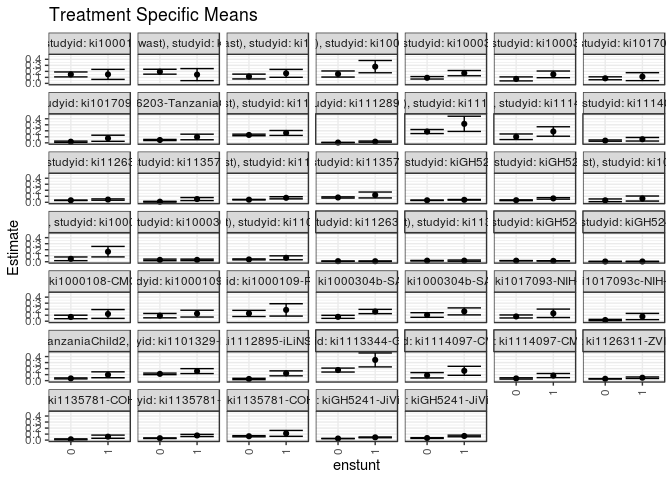

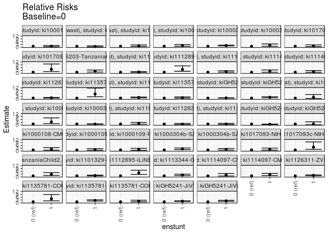

[figure not shown]

[figure not shown]

## Results Table

### Parameter: TSM

| agecat | studyid | country | intervention_level | baseline_level | estimate | ci_lower | ci_upper |
| --- | --- | --- | --- | --- | --- | --- | --- |
| 0-24 months (no birth wast) | ki1000108-CMC-V-BCS-2002 | INDIA | 0 | NA | 0.1490171 | 0.1081312 | 0.1899029 |
| 0-24 months (no birth wast) | ki1000108-CMC-V-BCS-2002 | INDIA | 1 | NA | 0.1498386 | 0.0663968 | 0.2332804 |
| 0-24 months (no birth wast) | ki1000108-IRC | INDIA | 0 | NA | 0.1939058 | 0.1530725 | 0.2347391 |
| 0-24 months (no birth wast) | ki1000108-IRC | INDIA | 1 | NA | 0.1458333 | 0.0458659 | 0.2458008 |
| 0-24 months (no birth wast) | ki1000109-EE | PAKISTAN | 0 | NA | 0.1138658 | 0.0740225 | 0.1537090 |
| 0-24 months (no birth wast) | ki1000109-EE | PAKISTAN | 1 | NA | 0.1669835 | 0.1014925 | 0.2324746 |
| 0-24 months (no birth wast) | ki1000109-ResPak | PAKISTAN | 0 | NA | 0.1559672 | 0.1052171 | 0.2067173 |
| 0-24 months (no birth wast) | ki1000109-ResPak | PAKISTAN | 1 | NA | 0.2782975 | 0.1765102 | 0.3800848 |
| 0-24 months (no birth wast) | ki1000304b-SAS-CompFeed | INDIA | 0 | NA | 0.0927861 | 0.0720711 | 0.1135011 |
| 0-24 months (no birth wast) | ki1000304b-SAS-CompFeed | INDIA | 1 | NA | 0.1705434 | 0.1269209 | 0.2141659 |
| 0-24 months (no birth wast) | ki1000304b-SAS-FoodSuppl | INDIA | 0 | NA | 0.0745873 | 0.0417114 | 0.1074632 |
| 0-24 months (no birth wast) | ki1000304b-SAS-FoodSuppl | INDIA | 1 | NA | 0.1501790 | 0.0946877 | 0.2056703 |
| 0-24 months (no birth wast) | ki1017093-NIH-Birth | BANGLADESH | 0 | NA | 0.0845783 | 0.0603291 | 0.1088276 |
| 0-24 months (no birth wast) | ki1017093-NIH-Birth | BANGLADESH | 1 | NA | 0.1119702 | 0.0456523 | 0.1782881 |
| 0-24 months (no birth wast) | ki1017093c-NIH-Crypto | BANGLADESH | 0 | NA | 0.0184900 | 0.0081188 | 0.0288612 |
| 0-24 months (no birth wast) | ki1017093c-NIH-Crypto | BANGLADESH | 1 | NA | 0.0761905 | 0.0254116 | 0.1269694 |
| 0-24 months (no birth wast) | ki1066203-TanzaniaChild2 | TANZANIA, UNITED REPUBLIC OF | 0 | NA | 0.0472201 | 0.0383964 | 0.0560437 |
| 0-24 months (no birth wast) | ki1066203-TanzaniaChild2 | TANZANIA, UNITED REPUBLIC OF | 1 | NA | 0.0974898 | 0.0510309 | 0.1439487 |
| 0-24 months (no birth wast) | ki1101329-Keneba | GAMBIA | 0 | NA | 0.1311092 | 0.1180013 | 0.1442170 |
| 0-24 months (no birth wast) | ki1101329-Keneba | GAMBIA | 1 | NA | 0.1639981 | 0.1228179 | 0.2051783 |
| 0-24 months (no birth wast) | ki1112895-iLiNS-Zinc | BURKINA FASO | 0 | NA | 0.0048996 | 0.0014609 | 0.0083382 |
| 0-24 months (no birth wast) | ki1112895-iLiNS-Zinc | BURKINA FASO | 1 | NA | 0.0196529 | 0.0097773 | 0.0295286 |
| 0-24 months (no birth wast) | ki1113344-GMS-Nepal | NEPAL | 0 | NA | 0.1877077 | 0.1541962 | 0.2212192 |
| 0-24 months (no birth wast) | ki1113344-GMS-Nepal | NEPAL | 1 | NA | 0.3158823 | 0.1893573 | 0.4424073 |
| 0-24 months (no birth wast) | ki1114097-CMIN | BANGLADESH | 0 | NA | 0.1007814 | 0.0542389 | 0.1473238 |
| 0-24 months (no birth wast) | ki1114097-CMIN | BANGLADESH | 1 | NA | 0.1887084 | 0.1100665 | 0.2673503 |
| 0-24 months (no birth wast) | ki1114097-CMIN | GUINEA-BISSAU | 0 | NA | 0.0370234 | 0.0265036 | 0.0475432 |
| 0-24 months (no birth wast) | ki1114097-CMIN | GUINEA-BISSAU | 1 | NA | 0.0595803 | 0.0297360 | 0.0894246 |
| 0-24 months (no birth wast) | ki1126311-ZVITAMBO | ZIMBABWE | 0 | NA | 0.0331712 | 0.0299935 | 0.0363488 |
| 0-24 months (no birth wast) | ki1126311-ZVITAMBO | ZIMBABWE | 1 | NA | 0.0454089 | 0.0342331 | 0.0565846 |

[output cut: 64 more lines]

### Parameter: E(Y)

| agecat | studyid | country | intervention_level | baseline_level | estimate | ci_lower | ci_upper |
| --- | --- | --- | --- | --- | --- | --- | --- |
| 0-24 months (no birth wast) | ki1000108-CMC-V-BCS-2002 | INDIA | NA | NA | 0.1494565 | 0.1129794 | 0.1859337 |
| 0-24 months (no birth wast) | ki1000108-IRC | INDIA | NA | NA | 0.1882641 | 0.1503318 | 0.2261964 |
| 0-24 months (no birth wast) | ki1000109-EE | PAKISTAN | NA | NA | 0.1352785 | 0.1007079 | 0.1698491 |
| 0-24 months (no birth wast) | ki1000109-ResPak | PAKISTAN | NA | NA | 0.1897810 | 0.1432659 | 0.2362962 |
| 0-24 months (no birth wast) | ki1000304b-SAS-CompFeed | INDIA | NA | NA | 0.1145140 | 0.0913579 | 0.1376700 |
| 0-24 months (no birth wast) | ki1000304b-SAS-FoodSuppl | INDIA | NA | NA | 0.1007557 | 0.0711091 | 0.1304022 |
| 0-24 months (no birth wast) | ki1017093-NIH-Birth | BANGLADESH | NA | NA | 0.0897010 | 0.0668555 | 0.1125465 |
| 0-24 months (no birth wast) | ki1017093c-NIH-Crypto | BANGLADESH | NA | NA | 0.0265252 | 0.0150478 | 0.0380026 |
| 0-24 months (no birth wast) | ki1066203-TanzaniaChild2 | TANZANIA, UNITED REPUBLIC OF | NA | NA | 0.0507550 | 0.0419422 | 0.0595679 |
| 0-24 months (no birth wast) | ki1101329-Keneba | GAMBIA | NA | NA | 0.1342867 | 0.1218039 | 0.1467696 |
| 0-24 months (no birth wast) | ki1112895-iLiNS-Zinc | BURKINA FASO | NA | NA | 0.0080880 | 0.0040249 | 0.0121511 |
| 0-24 months (no birth wast) | ki1113344-GMS-Nepal | NEPAL | NA | NA | 0.1983051 | 0.1661046 | 0.2305055 |
| 0-24 months (no birth wast) | ki1114097-CMIN | BANGLADESH | NA | NA | 0.1380597 | 0.0966822 | 0.1794372 |
| 0-24 months (no birth wast) | ki1114097-CMIN | GUINEA-BISSAU | NA | NA | 0.0413333 | 0.0312563 | 0.0514103 |
| 0-24 months (no birth wast) | ki1126311-ZVITAMBO | ZIMBABWE | NA | NA | 0.0344245 | 0.0313630 | 0.0374861 |
| 0-24 months (no birth wast) | ki1135781-COHORTS | GUATEMALA | NA | NA | 0.0202703 | 0.0126995 | 0.0278411 |
| 0-24 months (no birth wast) | ki1135781-COHORTS | INDIA | NA | NA | 0.0472320 | 0.0423094 | 0.0521545 |
| 0-24 months (no birth wast) | ki1135781-COHORTS | PHILIPPINES | NA | NA | 0.0824776 | 0.0726632 | 0.0922921 |
| 0-24 months (no birth wast) | kiGH5241-JiVitA-3 | BANGLADESH | NA | NA | 0.0356914 | 0.0331158 | 0.0382671 |
| 0-24 months (no birth wast) | kiGH5241-JiVitA-4 | BANGLADESH | NA | NA | 0.0429948 | 0.0372768 | 0.0487128 |
| 0-6 months (no birth wast) | ki1000109-EE | PAKISTAN | NA | NA | 0.0428954 | 0.0223052 | 0.0634857 |
| 0-6 months (no birth wast) | ki1000109-ResPak | PAKISTAN | NA | NA | 0.0808824 | 0.0484203 | 0.1133444 |
| 0-6 months (no birth wast) | ki1000304b-SAS-CompFeed | INDIA | NA | NA | 0.0312288 | 0.0186884 | 0.0437692 |
| 0-6 months (no birth wast) | ki1101329-Keneba | GAMBIA | NA | NA | 0.0410788 | 0.0331533 | 0.0490044 |
| 0-6 months (no birth wast) | ki1126311-ZVITAMBO | ZIMBABWE | NA | NA | 0.0098032 | 0.0081326 | 0.0114737 |
| 0-6 months (no birth wast) | ki1135781-COHORTS | INDIA | NA | NA | 0.0179724 | 0.0147449 | 0.0211998 |
| 0-6 months (no birth wast) | kiGH5241-JiVitA-3 | BANGLADESH | NA | NA | 0.0165409 | 0.0147291 | 0.0183527 |
| 0-6 months (no birth wast) | kiGH5241-JiVitA-4 | BANGLADESH | NA | NA | 0.0042364 | 0.0017272 | 0.0067456 |
| 6-24 months | ki1000108-CMC-V-BCS-2002 | INDIA | NA | NA | 0.0804290 | 0.0527929 | 0.1080650 |
| 6-24 months | ki1000109-EE | PAKISTAN | NA | NA | 0.1040000 | 0.0730627 | 0.1349373 |
| 6-24 months | ki1000109-ResPak | PAKISTAN | NA | NA | 0.1434783 | 0.0980744 | 0.1888821 |
| 6-24 months | ki1000304b-SAS-CompFeed | INDIA | NA | NA | 0.0964723 | 0.0729872 | 0.1199573 |
| 6-24 months | ki1000304b-SAS-FoodSuppl | INDIA | NA | NA | 0.1268657 | 0.0942904 | 0.1594410 |
| 6-24 months | ki1017093-NIH-Birth | BANGLADESH | NA | NA | 0.0868762 | 0.0631205 | 0.1106318 |
| 6-24 months | ki1017093c-NIH-Crypto | BANGLADESH | NA | NA | 0.0273973 | 0.0155476 | 0.0392469 |
| 6-24 months | ki1066203-TanzaniaChild2 | TANZANIA, UNITED REPUBLIC OF | NA | NA | 0.0411298 | 0.0324631 | 0.0497965 |
| 6-24 months | ki1101329-Keneba | GAMBIA | NA | NA | 0.1172389 | 0.1051866 | 0.1292911 |
| 6-24 months | ki1112895-iLiNS-Zinc | BURKINA FASO | NA | NA | 0.0505205 | 0.0383088 | 0.0627322 |
| 6-24 months | ki1113344-GMS-Nepal | NEPAL | NA | NA | 0.1915254 | 0.1597467 | 0.2233042 |
| 6-24 months | ki1114097-CMIN | BANGLADESH | NA | NA | 0.1150794 | 0.0756007 | 0.1545580 |
| 6-24 months | ki1114097-CMIN | GUINEA-BISSAU | NA | NA | 0.0452092 | 0.0346279 | 0.0557905 |
| 6-24 months | ki1126311-ZVITAMBO | ZIMBABWE | NA | NA | 0.0325416 | 0.0291786 | 0.0359047 |
| 6-24 months | ki1135781-COHORTS | GUATEMALA | NA | NA | 0.0245902 | 0.0158961 | 0.0332842 |
| 6-24 months | ki1135781-COHORTS | INDIA | NA | NA | 0.0368823 | 0.0324481 | 0.0413165 |
| 6-24 months | ki1135781-COHORTS | PHILIPPINES | NA | NA | 0.0669277 | 0.0576848 | 0.0761707 |
| 6-24 months | kiGH5241-JiVitA-3 | BANGLADESH | NA | NA | 0.0319690 | 0.0290813 | 0.0348568 |
| 6-24 months | kiGH5241-JiVitA-4 | BANGLADESH | NA | NA | 0.0440147 | 0.0381801 | 0.0498493 |

### Parameter: RR

| agecat | studyid | country | intervention_level | baseline_level | estimate | ci_lower | ci_upper |
| --- | --- | --- | --- | --- | --- | --- | --- |
| 0-24 months (no birth wast) | ki1000108-CMC-V-BCS-2002 | INDIA | 0 | 0 | 1.0000000 | 1.0000000 | 1.000000 |
| 0-24 months (no birth wast) | ki1000108-CMC-V-BCS-2002 | INDIA | 1 | 0 | 1.0055131 | 0.5401167 | 1.871922 |
| 0-24 months (no birth wast) | ki1000108-IRC | INDIA | 0 | 0 | 1.0000000 | 1.0000000 | 1.000000 |
| 0-24 months (no birth wast) | ki1000108-IRC | INDIA | 1 | 0 | 0.7520833 | 0.3671386 | 1.540643 |
| 0-24 months (no birth wast) | ki1000109-EE | PAKISTAN | 0 | 0 | 1.0000000 | 1.0000000 | 1.000000 |
| 0-24 months (no birth wast) | ki1000109-EE | PAKISTAN | 1 | 0 | 1.4664942 | 0.8688698 | 2.475175 |
| 0-24 months (no birth wast) | ki1000109-ResPak | PAKISTAN | 0 | 0 | 1.0000000 | 1.0000000 | 1.000000 |
| 0-24 months (no birth wast) | ki1000109-ResPak | PAKISTAN | 1 | 0 | 1.7843332 | 1.0975452 | 2.900879 |
| 0-24 months (no birth wast) | ki1000304b-SAS-CompFeed | INDIA | 0 | 0 | 1.0000000 | 1.0000000 | 1.000000 |
| 0-24 months (no birth wast) | ki1000304b-SAS-CompFeed | INDIA | 1 | 0 | 1.8380274 | 1.4708345 | 2.296890 |
| 0-24 months (no birth wast) | ki1000304b-SAS-FoodSuppl | INDIA | 0 | 0 | 1.0000000 | 1.0000000 | 1.000000 |
| 0-24 months (no birth wast) | ki1000304b-SAS-FoodSuppl | INDIA | 1 | 0 | 2.0134672 | 1.1326737 | 3.579186 |
| 0-24 months (no birth wast) | ki1017093-NIH-Birth | BANGLADESH | 0 | 0 | 1.0000000 | 1.0000000 | 1.000000 |
| 0-24 months (no birth wast) | ki1017093-NIH-Birth | BANGLADESH | 1 | 0 | 1.3238637 | 0.6857090 | 2.555917 |
| 0-24 months (no birth wast) | ki1017093c-NIH-Crypto | BANGLADESH | 0 | 0 | 1.0000000 | 1.0000000 | 1.000000 |
| 0-24 months (no birth wast) | ki1017093c-NIH-Crypto | BANGLADESH | 1 | 0 | 4.1206348 | 1.7244576 | 9.846361 |
| 0-24 months (no birth wast) | ki1066203-TanzaniaChild2 | TANZANIA, UNITED REPUBLIC OF | 0 | 0 | 1.0000000 | 1.0000000 | 1.000000 |
| 0-24 months (no birth wast) | ki1066203-TanzaniaChild2 | TANZANIA, UNITED REPUBLIC OF | 1 | 0 | 2.0645839 | 1.2374064 | 3.444710 |
| 0-24 months (no birth wast) | ki1101329-Keneba | GAMBIA | 0 | 0 | 1.0000000 | 1.0000000 | 1.000000 |
| 0-24 months (no birth wast) | ki1101329-Keneba | GAMBIA | 1 | 0 | 1.2508515 | 0.9551126 | 1.638162 |
| 0-24 months (no birth wast) | ki1112895-iLiNS-Zinc | BURKINA FASO | 0 | 0 | 1.0000000 | 1.0000000 | 1.000000 |
| 0-24 months (no birth wast) | ki1112895-iLiNS-Zinc | BURKINA FASO | 1 | 0 | 4.0111672 | 2.0549888 | 7.829465 |
| 0-24 months (no birth wast) | ki1113344-GMS-Nepal | NEPAL | 0 | 0 | 1.0000000 | 1.0000000 | 1.000000 |
| 0-24 months (no birth wast) | ki1113344-GMS-Nepal | NEPAL | 1 | 0 | 1.6828414 | 1.0852287 | 2.609547 |
| 0-24 months (no birth wast) | ki1114097-CMIN | BANGLADESH | 0 | 0 | 1.0000000 | 1.0000000 | 1.000000 |
| 0-24 months (no birth wast) | ki1114097-CMIN | BANGLADESH | 1 | 0 | 1.8724531 | 1.0044841 | 3.490429 |
| 0-24 months (no birth wast) | ki1114097-CMIN | GUINEA-BISSAU | 0 | 0 | 1.0000000 | 1.0000000 | 1.000000 |
| 0-24 months (no birth wast) | ki1114097-CMIN | GUINEA-BISSAU | 1 | 0 | 1.6092605 | 0.9046465 | 2.862687 |
| 0-24 months (no birth wast) | ki1126311-ZVITAMBO | ZIMBABWE | 0 | 0 | 1.0000000 | 1.0000000 | 1.000000 |
| 0-24 months (no birth wast) | ki1126311-ZVITAMBO | ZIMBABWE | 1 | 0 | 1.3689249 | 1.0512425 | 1.782610 |

[output cut: 64 more lines]

### Parameter: PAR

| agecat | studyid | country | intervention_level | baseline_level | estimate | ci_lower | ci_upper |
| --- | --- | --- | --- | --- | --- | --- | --- |
| 0-24 months (no birth wast) | ki1000108-CMC-V-BCS-2002 | INDIA | 0 | NA | 0.0004394 | -0.0179954 | 0.0188743 |
| 0-24 months (no birth wast) | ki1000108-IRC | INDIA | 0 | NA | -0.0056418 | -0.0184035 | 0.0071200 |
| 0-24 months (no birth wast) | ki1000109-EE | PAKISTAN | 0 | NA | 0.0214127 | -0.0050725 | 0.0478979 |
| 0-24 months (no birth wast) | ki1000109-ResPak | PAKISTAN | 0 | NA | 0.0338138 | 0.0028970 | 0.0647306 |
| 0-24 months (no birth wast) | ki1000304b-SAS-CompFeed | INDIA | 0 | NA | 0.0217279 | 0.0128981 | 0.0305577 |
| 0-24 months (no birth wast) | ki1000304b-SAS-FoodSuppl | INDIA | 0 | NA | 0.0261684 | 0.0010224 | 0.0513144 |
| 0-24 months (no birth wast) | ki1017093-NIH-Birth | BANGLADESH | 0 | NA | 0.0051227 | -0.0057859 | 0.0160312 |
| 0-24 months (no birth wast) | ki1017093c-NIH-Crypto | BANGLADESH | 0 | NA | 0.0080352 | 0.0006782 | 0.0153922 |
| 0-24 months (no birth wast) | ki1066203-TanzaniaChild2 | TANZANIA, UNITED REPUBLIC OF | 0 | NA | 0.0035350 | 0.0003108 | 0.0067591 |
| 0-24 months (no birth wast) | ki1101329-Keneba | GAMBIA | 0 | NA | 0.0031775 | -0.0014707 | 0.0078258 |
| 0-24 months (no birth wast) | ki1112895-iLiNS-Zinc | BURKINA FASO | 0 | NA | 0.0031884 | 0.0013538 | 0.0050231 |
| 0-24 months (no birth wast) | ki1113344-GMS-Nepal | NEPAL | 0 | NA | 0.0105974 | -0.0023154 | 0.0235102 |
| 0-24 months (no birth wast) | ki1114097-CMIN | BANGLADESH | 0 | NA | 0.0372783 | 0.0023045 | 0.0722522 |
| 0-24 months (no birth wast) | ki1114097-CMIN | GUINEA-BISSAU | 0 | NA | 0.0043099 | -0.0010990 | 0.0097188 |
| 0-24 months (no birth wast) | ki1126311-ZVITAMBO | ZIMBABWE | 0 | NA | 0.0012534 | 0.0000790 | 0.0024277 |
| 0-24 months (no birth wast) | ki1135781-COHORTS | GUATEMALA | 0 | NA | 0.0103867 | 0.0042173 | 0.0165562 |
| 0-24 months (no birth wast) | ki1135781-COHORTS | INDIA | 0 | NA | 0.0037179 | 0.0015191 | 0.0059167 |
| 0-24 months (no birth wast) | ki1135781-COHORTS | PHILIPPINES | 0 | NA | 0.0024025 | -0.0004663 | 0.0052713 |
| 0-24 months (no birth wast) | kiGH5241-JiVitA-3 | BANGLADESH | 0 | NA | 0.0025413 | 0.0007975 | 0.0042851 |
| 0-24 months (no birth wast) | kiGH5241-JiVitA-4 | BANGLADESH | 0 | NA | 0.0086907 | 0.0046397 | 0.0127417 |
| 0-6 months (no birth wast) | ki1000109-EE | PAKISTAN | 0 | NA | 0.0101086 | -0.0063115 | 0.0265286 |
| 0-6 months (no birth wast) | ki1000109-ResPak | PAKISTAN | 0 | NA | 0.0318134 | 0.0069134 | 0.0567134 |
| 0-6 months (no birth wast) | ki1000304b-SAS-CompFeed | INDIA | 0 | NA | 0.0002448 | -0.0016692 | 0.0021589 |
| 0-6 months (no birth wast) | ki1101329-Keneba | GAMBIA | 0 | NA | 0.0025707 | -0.0005898 | 0.0057312 |
| 0-6 months (no birth wast) | ki1126311-ZVITAMBO | ZIMBABWE | 0 | NA | -0.0001473 | -0.0006627 | 0.0003681 |
| 0-6 months (no birth wast) | ki1135781-COHORTS | INDIA | 0 | NA | 0.0000677 | -0.0010718 | 0.0012071 |
| 0-6 months (no birth wast) | kiGH5241-JiVitA-3 | BANGLADESH | 0 | NA | -0.0010089 | -0.0021115 | 0.0000938 |
| 0-6 months (no birth wast) | kiGH5241-JiVitA-4 | BANGLADESH | 0 | NA | 0.0000300 | -0.0014141 | 0.0014742 |
| 6-24 months | ki1000108-CMC-V-BCS-2002 | INDIA | 0 | NA | 0.0099592 | -0.0060897 | 0.0260080 |
| 6-24 months | ki1000109-EE | PAKISTAN | 0 | NA | 0.0117573 | -0.0116190 | 0.0351335 |
| 6-24 months | ki1000109-ResPak | PAKISTAN | 0 | NA | 0.0145218 | -0.0145727 | 0.0436163 |
| 6-24 months | ki1000304b-SAS-CompFeed | INDIA | 0 | NA | 0.0245427 | 0.0136032 | 0.0354822 |
| 6-24 months | ki1000304b-SAS-FoodSuppl | INDIA | 0 | NA | 0.0238158 | -0.0036440 | 0.0512756 |
| 6-24 months | ki1017093-NIH-Birth | BANGLADESH | 0 | NA | 0.0080495 | -0.0039863 | 0.0200853 |
| 6-24 months | ki1017093c-NIH-Crypto | BANGLADESH | 0 | NA | 0.0082585 | 0.0006596 | 0.0158574 |
| 6-24 months | ki1066203-TanzaniaChild2 | TANZANIA, UNITED REPUBLIC OF | 0 | NA | 0.0038821 | 0.0004393 | 0.0073248 |
| 6-24 months | ki1101329-Keneba | GAMBIA | 0 | NA | 0.0045895 | -0.0001465 | 0.0093255 |
| 6-24 months | ki1112895-iLiNS-Zinc | BURKINA FASO | 0 | NA | 0.0225178 | 0.0137763 | 0.0312593 |
| 6-24 months | ki1113344-GMS-Nepal | NEPAL | 0 | NA | 0.0154575 | 0.0021909 | 0.0287242 |
| 6-24 months | ki1114097-CMIN | BANGLADESH | 0 | NA | 0.0257102 | -0.0069565 | 0.0583768 |
| 6-24 months | ki1114097-CMIN | GUINEA-BISSAU | 0 | NA | 0.0083819 | 0.0020859 | 0.0146778 |
| 6-24 months | ki1126311-ZVITAMBO | ZIMBABWE | 0 | NA | 0.0019459 | 0.0005551 | 0.0033368 |
| 6-24 months | ki1135781-COHORTS | GUATEMALA | 0 | NA | 0.0112949 | 0.0043047 | 0.0182852 |
| 6-24 months | ki1135781-COHORTS | INDIA | 0 | NA | 0.0054454 | 0.0031847 | 0.0077060 |
| 6-24 months | ki1135781-COHORTS | PHILIPPINES | 0 | NA | 0.0027230 | -0.0001569 | 0.0056029 |
| 6-24 months | kiGH5241-JiVitA-3 | BANGLADESH | 0 | NA | 0.0059818 | 0.0038392 | 0.0081244 |
| 6-24 months | kiGH5241-JiVitA-4 | BANGLADESH | 0 | NA | 0.0099127 | 0.0056035 | 0.0142219 |

### Parameter: PAF

| agecat | studyid | country | intervention_level | baseline_level | estimate | ci_lower | ci_upper |
| --- | --- | --- | --- | --- | --- | --- | --- |
| 0-24 months (no birth wast) | ki1000108-CMC-V-BCS-2002 | INDIA | 0 | NA | 0.0029403 | -0.1283626 | 0.1189641 |
| 0-24 months (no birth wast) | ki1000108-IRC | INDIA | 0 | NA | -0.0299673 | -0.0998838 | 0.0355049 |
| 0-24 months (no birth wast) | ki1000109-EE | PAKISTAN | 0 | NA | 0.1582863 | -0.0587784 | 0.3308497 |
| 0-24 months (no birth wast) | ki1000109-ResPak | PAKISTAN | 0 | NA | 0.1781727 | 0.0009471 | 0.3239596 |
| 0-24 months (no birth wast) | ki1000304b-SAS-CompFeed | INDIA | 0 | NA | 0.1897401 | 0.1178836 | 0.2557432 |
| 0-24 months (no birth wast) | ki1000304b-SAS-FoodSuppl | INDIA | 0 | NA | 0.2597214 | -0.0223541 | 0.4639701 |
| 0-24 months (no birth wast) | ki1017093-NIH-Birth | BANGLADESH | 0 | NA | 0.0571083 | -0.0719243 | 0.1706086 |
| 0-24 months (no birth wast) | ki1017093c-NIH-Crypto | BANGLADESH | 0 | NA | 0.3029276 | 0.0082660 | 0.5100400 |
| 0-24 months (no birth wast) | ki1066203-TanzaniaChild2 | TANZANIA, UNITED REPUBLIC OF | 0 | NA | 0.0696475 | 0.0050059 | 0.1300896 |
| 0-24 months (no birth wast) | ki1101329-Keneba | GAMBIA | 0 | NA | 0.0236624 | -0.0115354 | 0.0576354 |
| 0-24 months (no birth wast) | ki1112895-iLiNS-Zinc | BURKINA FASO | 0 | NA | 0.3942186 | 0.1498091 | 0.5683663 |
| 0-24 months (no birth wast) | ki1113344-GMS-Nepal | NEPAL | 0 | NA | 0.0534397 | -0.0136862 | 0.1161205 |
| 0-24 months (no birth wast) | ki1114097-CMIN | BANGLADESH | 0 | NA | 0.2700161 | -0.0205457 | 0.4778514 |
| 0-24 months (no birth wast) | ki1114097-CMIN | GUINEA-BISSAU | 0 | NA | 0.1042722 | -0.0340339 | 0.2240793 |
| 0-24 months (no birth wast) | ki1126311-ZVITAMBO | ZIMBABWE | 0 | NA | 0.0364090 | 0.0018315 | 0.0697887 |
| 0-24 months (no birth wast) | ki1135781-COHORTS | GUATEMALA | 0 | NA | 0.5124121 | 0.2053525 | 0.7008208 |
| 0-24 months (no birth wast) | ki1135781-COHORTS | INDIA | 0 | NA | 0.0787150 | 0.0316513 | 0.1234912 |
| 0-24 months (no birth wast) | ki1135781-COHORTS | PHILIPPINES | 0 | NA | 0.0291295 | -0.0061476 | 0.0631696 |
| 0-24 months (no birth wast) | kiGH5241-JiVitA-3 | BANGLADESH | 0 | NA | 0.0712012 | 0.0212872 | 0.1185696 |
| 0-24 months (no birth wast) | kiGH5241-JiVitA-4 | BANGLADESH | 0 | NA | 0.2021334 | 0.1016802 | 0.2913536 |
| 0-6 months (no birth wast) | ki1000109-EE | PAKISTAN | 0 | NA | 0.2356557 | -0.2352502 | 0.5270414 |
| 0-6 months (no birth wast) | ki1000109-ResPak | PAKISTAN | 0 | NA | 0.3933290 | 0.0481433 | 0.6133350 |
| 0-6 months (no birth wast) | ki1000304b-SAS-CompFeed | INDIA | 0 | NA | 0.0078402 | -0.0559026 | 0.0677349 |
| 0-6 months (no birth wast) | ki1101329-Keneba | GAMBIA | 0 | NA | 0.0625793 | -0.0167151 | 0.1356895 |
| 0-6 months (no birth wast) | ki1126311-ZVITAMBO | ZIMBABWE | 0 | NA | -0.0150260 | -0.0689092 | 0.0361410 |
| 0-6 months (no birth wast) | ki1135781-COHORTS | INDIA | 0 | NA | 0.0037654 | -0.0616958 | 0.0651904 |
| 0-6 months (no birth wast) | kiGH5241-JiVitA-3 | BANGLADESH | 0 | NA | -0.0609913 | -0.1293970 | 0.0032711 |
| 0-6 months (no birth wast) | kiGH5241-JiVitA-4 | BANGLADESH | 0 | NA | 0.0070908 | -0.4007295 | 0.2961748 |
| 6-24 months | ki1000108-CMC-V-BCS-2002 | INDIA | 0 | NA | 0.1238255 | -0.0954049 | 0.2991799 |
| 6-24 months | ki1000109-EE | PAKISTAN | 0 | NA | 0.1130507 | -0.1401896 | 0.3100453 |
| 6-24 months | ki1000109-ResPak | PAKISTAN | 0 | NA | 0.1012125 | -0.1242175 | 0.2814389 |
| 6-24 months | ki1000304b-SAS-CompFeed | INDIA | 0 | NA | 0.2544016 | 0.1175155 | 0.3700546 |
| 6-24 months | ki1000304b-SAS-FoodSuppl | INDIA | 0 | NA | 0.1877245 | -0.0550604 | 0.3746411 |
| 6-24 months | ki1017093-NIH-Birth | BANGLADESH | 0 | NA | 0.0926551 | -0.0549104 | 0.2195784 |
| 6-24 months | ki1017093c-NIH-Crypto | BANGLADESH | 0 | NA | 0.3014354 | 0.0063132 | 0.5089071 |
| 6-24 months | ki1066203-TanzaniaChild2 | TANZANIA, UNITED REPUBLIC OF | 0 | NA | 0.0943853 | 0.0091140 | 0.1723186 |
| 6-24 months | ki1101329-Keneba | GAMBIA | 0 | NA | 0.0391468 | -0.0019732 | 0.0785792 |
| 6-24 months | ki1112895-iLiNS-Zinc | BURKINA FASO | 0 | NA | 0.4457158 | 0.2715723 | 0.5782272 |
| 6-24 months | ki1113344-GMS-Nepal | NEPAL | 0 | NA | 0.0807076 | 0.0093692 | 0.1469086 |
| 6-24 months | ki1114097-CMIN | BANGLADESH | 0 | NA | 0.2234123 | -0.1062940 | 0.4548570 |
| 6-24 months | ki1114097-CMIN | GUINEA-BISSAU | 0 | NA | 0.1854024 | 0.0411360 | 0.3079631 |
| 6-24 months | ki1126311-ZVITAMBO | ZIMBABWE | 0 | NA | 0.0597985 | 0.0165285 | 0.1011648 |
| 6-24 months | ki1135781-COHORTS | GUATEMALA | 0 | NA | 0.4593275 | 0.1653743 | 0.6497511 |
| 6-24 months | ki1135781-COHORTS | INDIA | 0 | NA | 0.1476419 | 0.0866832 | 0.2045320 |
| 6-24 months | ki1135781-COHORTS | PHILIPPINES | 0 | NA | 0.0406859 | -0.0029967 | 0.0824660 |
| 6-24 months | kiGH5241-JiVitA-3 | BANGLADESH | 0 | NA | 0.1871127 | 0.1206336 | 0.2485660 |
| 6-24 months | kiGH5241-JiVitA-4 | BANGLADESH | 0 | NA | 0.2252143 | 0.1228137 | 0.3156609 |